# How to Roll 10d6, Repeated 1000 Times

And how to use the simulation to find a Margin of Error

*S-IC.A.2: Decide if a specified model is consistent with results from a given data-generating process, e.g., using simulation.*

## Introduction to Spreadsheet Simulation

This presentation will guide you through a simple simulation using a spreadsheet. We’ll be exploring the distribution of results when rolling 10 six-sided dice (10d6) and repeating this process 1000 times. This will introduce the concept of copying formulas and generating large datasets in a spreadsheet.

## Dice Notation

In role-playing games, “10d6” represents the sum of rolling ten six-sided dice.

## Rolling a Die

In a spreadsheet, we can use the `=RANDBETWEEN(1,6)` function to simulate rolling a single six-sided die.

## Rolling 10d6

- **Step 1:** Enter `=RANDBETWEEN(1,6)` into cell A1. This represents the first die.
- **Step 2:** Drag the formula from A1 to J1. This will copy the formula and generate ten dice rolls (10d6).

## Repeating the Roll 1000 Times

- **Step 1:** Highlight all ten dice rolls (A1:J1).
- **Step 2:** Press `Ctrl+Shift+Down` to highlight the range A1:J1000.
- **Step 3:** Press `Ctrl+Enter` to copy the formula to all cells in the highlighted range.

Now you have 1000 sets of 10d6 rolls!

## Calculating the Total

- **Step 1:** In cell L1, type `=SUM(A1:J1)` to calculate the sum of the first set of dice rolls.
- **Step 2:** Drag the formula in L1 down to L1000 to calculate the sums for all 1000 sets of 10d6 rolls.

**Important:** Whenever you make any change in the spreadsheet, all the dice rolls and sums are recalculated!

## Freezing the Data

To prevent further recalculation, we’ll need to freeze the data:

- **Step 1:** Select all cells using `Ctrl+A`.
- **Step 2:** Copy the selected cells with `Ctrl+C`.
- **Step 3:** Paste the copied cells as values only with `Ctrl+Shift+V`.

## Visualizing the Data

Let’s create a histogram to visualize the distribution of the 1000 sums:

- **Step 1:** Highlight the range L1:L1000.
- **Step 2:** Click **Insert**, then **Chart**.
- **Step 3:** Choose **Histogram** as the chart type.
- **Step 4:** Under **Customize**, click **Histogram**.
- **Step 5:** Set the **Bucket size** to 1.

## Exploring the Histogram

Take a moment to examine the histogram:

- **What is the smallest possible result of 10d6?**
- **What is the largest possible result of 10d6?**
- **Where is the center of the distribution?**
- **What would you consider a “typical” result of 10d6?**
- **What results would you consider “strange enough to raise an eyebrow”?**

## Defining the Interval of Typical Totals

We can use a standard method to define an interval of typical totals. This interval encompasses the middle 95% of the data, excluding the bottom 2.5% and top 2.5%.

- **Step 1:** Highlight column L.
- **Step 2:** Click **Data**, then **Sort sheet**.
- **Step 3:** Sort the sheet by column L (A to Z).
- **Step 4:** In a blank cell, type `=L26`. This represents the lower boundary of our interval, after excluding the bottom 2.5% (25 totals).
- **Step 5:** In another blank cell, type `=L975`. This represents the upper boundary of our interval, after excluding the top 2.5% (another 25 totals).

The values in the cells from step 4 and 5 are the boundaries of our interval of typical totals. The difference between these values, divided by 2, represents the **margin of error**. This margin of error is like a radius of the interval of typical totals, indicating how far from the center we can expect to see typical results.

## Dot plot visualization of interval

You should have gotten interval boundaries close to 25 and 45.

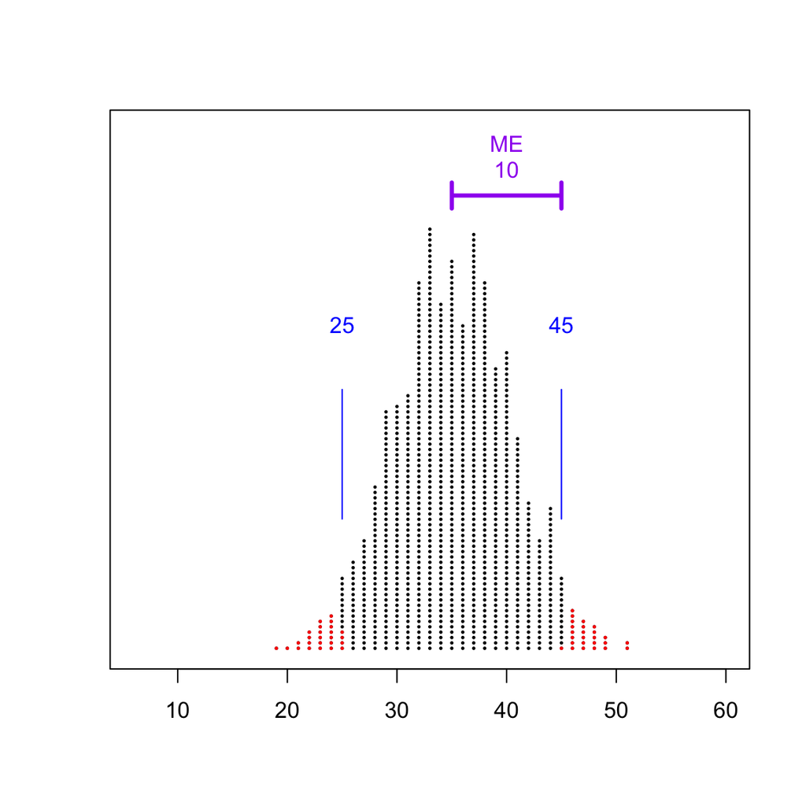

The margin of error is half the difference of the boundaries.

$$\mathrm{ME} = \frac{45-25}{2} =
10$$

## Incorrect usage of “Margin of Error”

- I’ve noticed some people use “Margin of Error” to mean “room for error”. For example, if someone is far ahead in a soccer match, they have some “room for error” not some “margin of error”.

## Raising an eyebrow

Let’s go back to the dot plot.

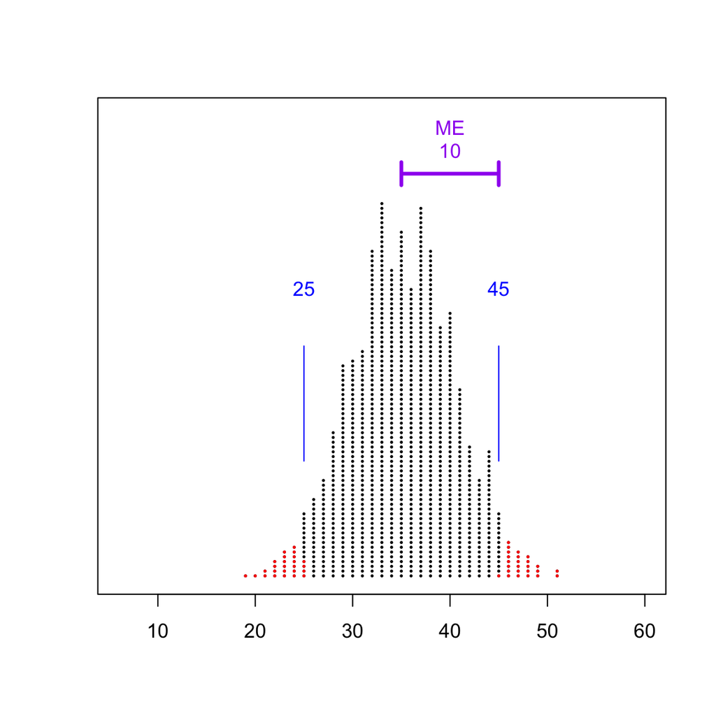

Let’s say you meet a stranger at a table-top role-playing game, and their first roll is 10d6, and they get a total of 55. What would you infer or conclude?

Personally, I’d raise an eyebrow and ask to inspect those dice. Some statisticians would say that 55 is “outside the margin of error”. What they really mean is 55 is farther from the expected value (about 35) than the margin of error, because 55-35=20, but ME=10. I feel it would be better to say “55 is outside the interval of typical totals”.

## Overview

- We introduced repeated simulations, where each round produces a summation of [independent and identically distributed random variables](https://en.wikipedia.org/wiki/Independent_and_identically_distributed_random_variables).
- We noticed those sums form a bell-shaped curve.
- We defined an interval of typical sums as the interval containing the middle 95% of the sums.
- We defined a margin or error as half this width of the interval of typical sums.
- We discussed the possibility of a real-world observation producing a sum outside the interval of typical sums, and we asked what that would possibly imply.